# Principal Components Analysis

January 08 2018

```r
library(hierfstat)
library(knitr)
library(scatterplot3d)
library(ggord)
library(tidyverse)
data(IGS)
```

# Detecting Population Structure with Principal Components Analysis

In what we have done so far, we have been able to partition genetic variation among levels - x percent within populations, y percent among populations within regions, etc. But what we haven’t been able to do is to establish relatedness among populations. So, for example, given some observed value of Fst, we do not know which populations differ from which others and by how much. Furthermore, we are imposing our expectation of how the population should be structured on the data - wouldn’t it be nice if we could “let the data do the talking” and empirically deter appropriate grouings. This is what we will do in what follows, first with Principal Components analysis and second with STRUCTURE, a Bayesian genotype assignment algorithm.

## The essence of PCA

PCA is, in simplest term, a way to reduce the dimensionality of multivariate data. In a genetic context, we could have populations with allele frequencies at multiple loci or (even better) individual multilocus genotypes. How do we take such variation and make sense of it, either visually or mathematically?

We’re going to start with a simple hypothetical example, in which we look at allele frequencies for two loci in eight populations:

```r
dat.samp <-data.frame(sample=1:8, p1=c(.32,.36,.58,.59,.78,.75,.85,.83),p2=c(.4,.55,.42,.78,.60,.90,.80,.95))
kable(dat.samp)
```

| sample | p1 | p2 |
| --- | --- | --- |
| 1 | 0.32 | 0.40 |
| 2 | 0.36 | 0.55 |
| 3 | 0.58 | 0.42 |
| 4 | 0.59 | 0.78 |
| 5 | 0.78 | 0.60 |
| 6 | 0.75 | 0.90 |
| 7 | 0.85 | 0.80 |
| 8 | 0.83 | 0.95 |

Now, let’s make an xy plot of the data:

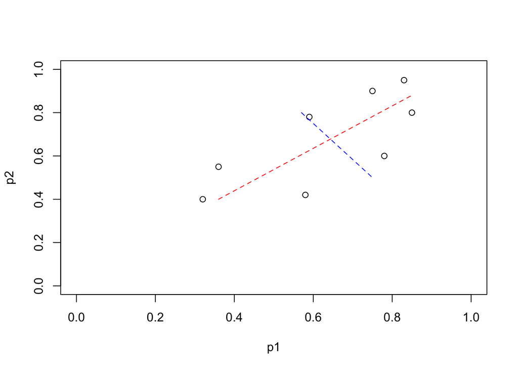

Dashed lines show the approximate position of perpendicular axes onto which the data can be mapped

```r
plot(dat.samp$p1,dat.samp$p2,ylim=c(0,1),xlim=c(0,1),xlab="p1",ylab="p2")
segments(.36,.4,.85,.88,lty=2,col="red")
segments(.57,.8,.75,.5,lty=2,col="blue")
```

When we look at these data, we see that the variation in it can be seen as having two dimensions, however those dimensions are not in the same orientation as the x and y axes of the graph. Rather, they are tilted, as is roughly visualized by the red and blue lines. So what we can imagine (and what pca does) is to rotate the data, and to center it on zero, such that now we have two axes that represent the variation in the data

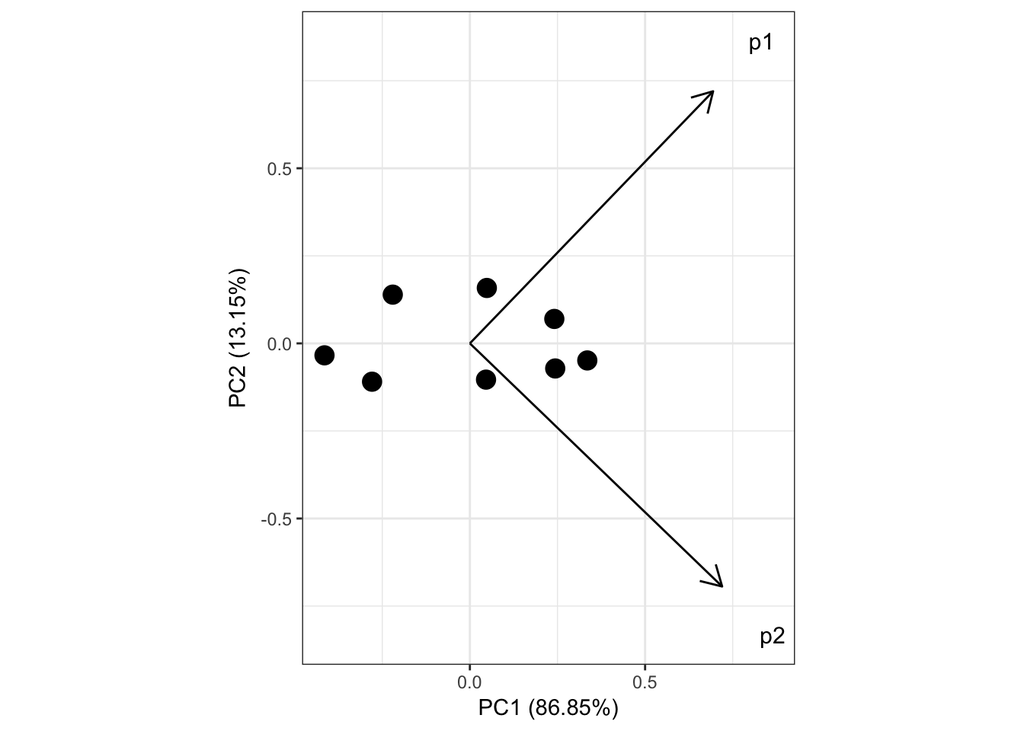

Normalized data have been remapped on those axes. Arrows indicate the loadings, or the magnitude of the contribution of each variable to each axis

```r
dat.pr <-prcomp(dat.samp[,2:3])
ggord(dat.pr)
```

```r
summary(dat.pr)
```

```
## Importance of components:
##                           PC1    PC2
## Standard deviation     0.2758 0.1073
## Proportion of Variance 0.8685 0.1315
## Cumulative Proportion  0.8685 1.0000
```

This is nothing special - we’ve rescaled the data such that we now can describe it in terms of two variance components, one of which (component 1) explains 86% of the variation in the data and the second explains 13%

But what if we add a third set of frequencies to the data?

```r
p3 <-c(.3,.4,.2,.3,.7,.8,.5,.6)
dat.samp3 <-cbind(dat.samp,p3)
```

Once again, we can plot the data, this time in three dimensions:

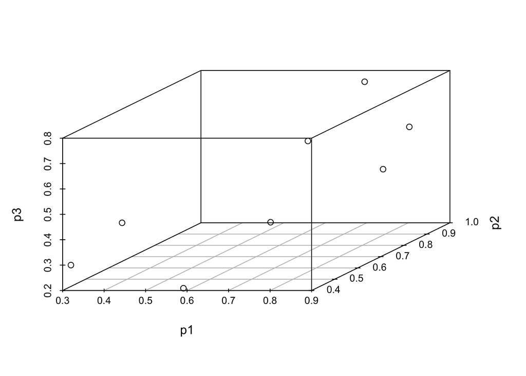

The three-variable data set, plotted in three dimensions

```r
scatterplot3d(dat.samp3[,2:4])
```

And now, how can we make any sense of it? This is where PCA begins to show its usefulness:

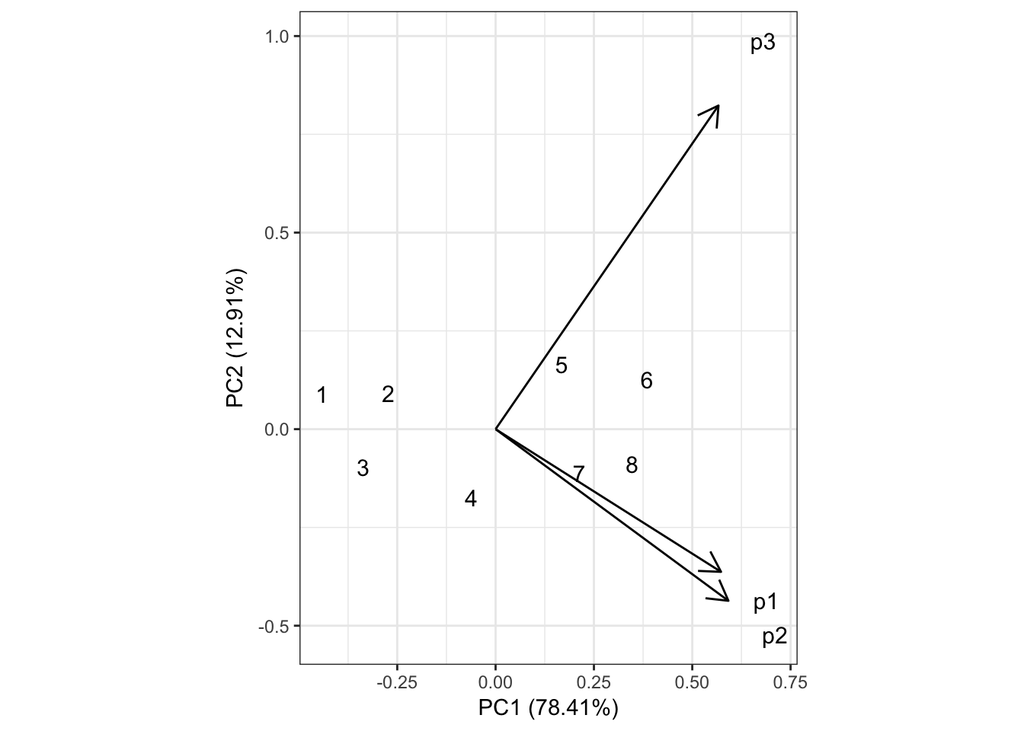

PCA of the three variable data

```r
samp3.pr <-prcomp(dat.samp3[,2:4])
ggord(samp3.pr,obslab=TRUE)
```

```r
summary(samp3.pr)
```

```
## Importance of components:
##                           PC1    PC2     PC3
## Standard deviation     0.3224 0.1308 0.10727
## Proportion of Variance 0.7841 0.1291 0.08679
## Cumulative Proportion  0.7841 0.9132 1.00000
```

Note that now, while the eight samples are relatively evenly distributed along PC1, PC2 clearly separates the samples into two groups - 1,2,5, and 6 vs. 3,4,7, and 8.

PCA is an example of what data scientists call “unsupervised learning”. If you are interested in learning more, this video is an excellent overview of the method:

[video not shown]

# Some real data

But enough of hypotheticals. Let’s see what we can do with genotype data, using the Idaho Giant Salamander (Mullen et al. (2010)) data as our source:

```r
kable(head(IGS))
```

| Catchment | Basin | Stream | 1 | 2 | 3 | 4 | 5 | 6 | 7 | 8 | 9 |
| --- | --- | --- | --- | --- | --- | --- | --- | --- | --- | --- | --- |
| Badger | Lochsa | LBU1 | 45 | 33 | 46 | 33 | 56 | 23 | 23 | 22 | 44 |
| Badger | Lochsa | LBU1 | 55 | 33 | 34 | 33 | 55 | 34 | 13 | 22 | 44 |
| Badger | Lochsa | LBU1 | 55 | 33 | 44 | 33 | 55 | 23 | 12 | 22 | 44 |
| Badger | Lochsa | LBU1 | 55 | 33 | 45 | 33 | 56 | 33 | 13 | 22 | 44 |
| Badger | Lochsa | LBU1 | 55 | 34 | 46 | 33 | 56 | 23 | 33 | 22 | 44 |
| Badger | Lochsa | LBU1 | 55 | 33 | 34 | 33 | 55 | 34 | 33 | 12 | 34 |

Notice that we are now working with individual genotypes, coded as 2 numbers. The important point to note is that when we do our PCA’s *the location information will not be incorporated into our analysis*. What we will do is to color code the the points on the plots, so that we can relate the PCA results to geography:

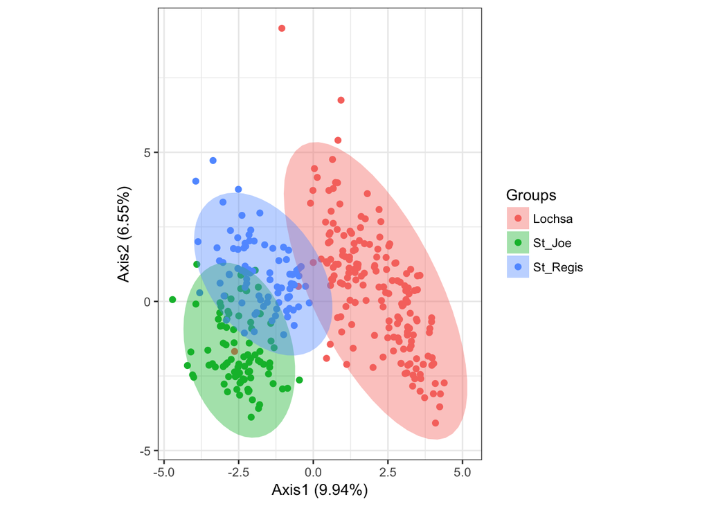

```r
dat.basin <-IGS[,c(2,4:12)]
basin.pca <-indpca(dat.basin)
#plot(basin.pca,cex=0.5,col=c(rep(1,180),rep(2,90),rep(3,91)),ax1=1,ax2=2)
ggord(basin.pca$ipca,dat.basin$Basin,size=2,vec_ext=0,txt=NULL,arrow=0)
```

And we can see that in fact the three basins do group separately, although the St. Joe and St. Regis overlap to a greater extent than does Lochsa with either of the others.

What is plotted is, of course, the first two PC’s, the ones that explain the greatest of the variance. In fact, given the multidimensionality of the data, there are many more PC’s we could look at. What we need to ask is How much of the variance are we explaining? We can plot

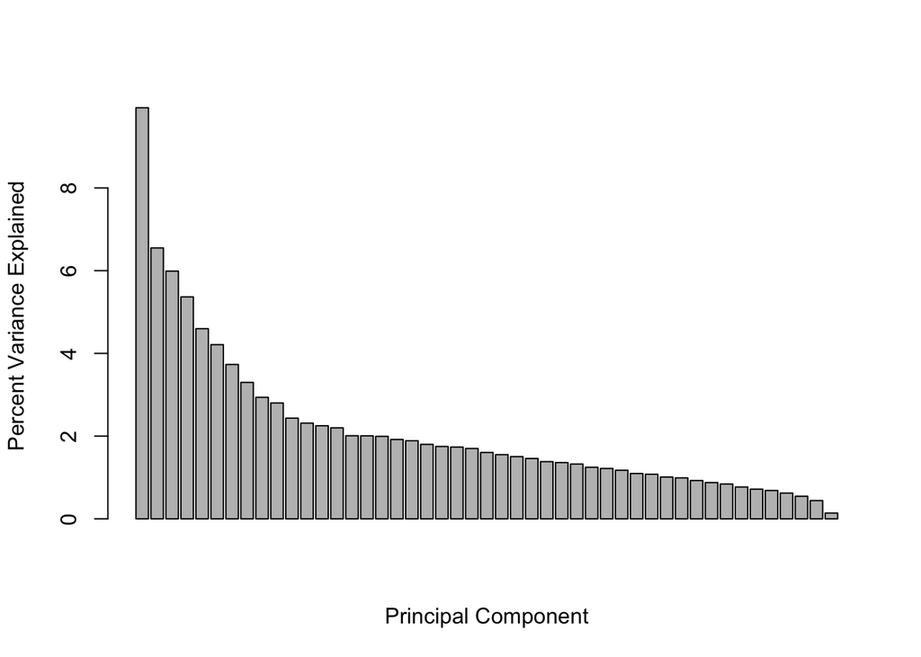

```r
barplot(100*basin.pca$ipca$eig/sum(basin.pca$ipca$eig),xlab="Principal Component",ylab="Percent Variance Explained")
```

In this case, taken together, the first two PC’s explain only about 17% of the variation between them - not an ideal situation. We could explore this further, but for now we’ll take another approach - use the same pca results but color the points by catchment:

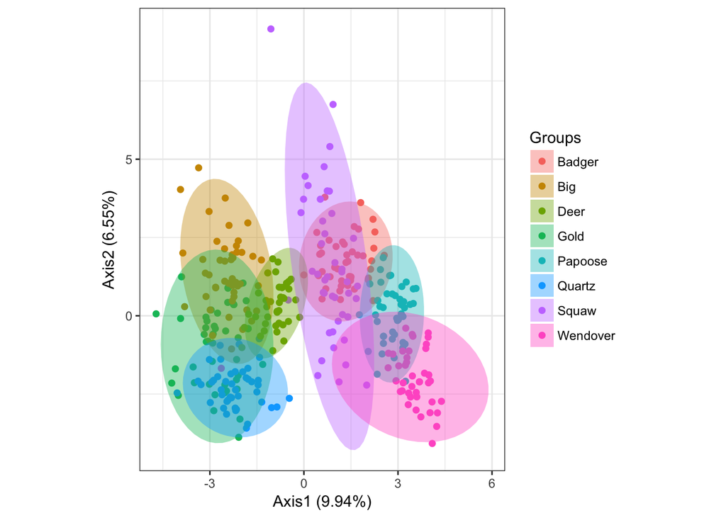

```r
ggord(basin.pca$ipca,IGS$Catchment,size=2,vec_ext=0,txt=NULL,arrow=0,ellipse=TRUE)
```

So we see that there is some degree of clustering by catchment, however the major division remains that between basins on axis 1. Could we learn more by looking at additional components? Remember that we just saw that they do explain significant amounts of variation. Let’s keep axis 1 in our comparison but now plot it against axis 3

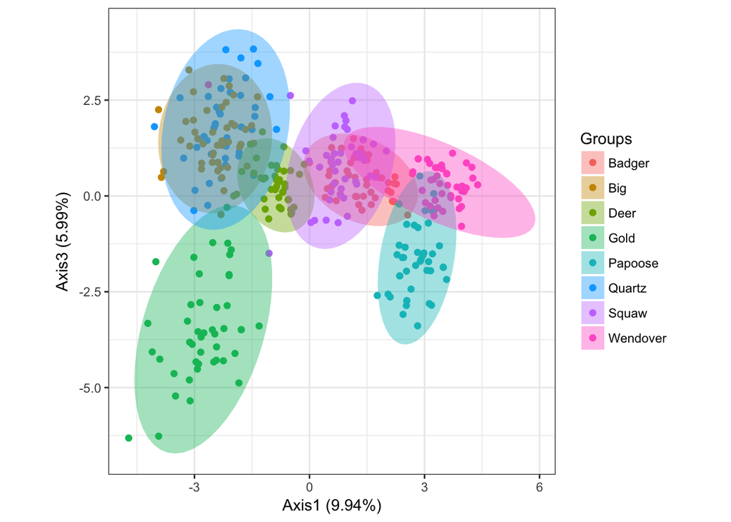

```r
ggord(basin.pca$ipca,IGS$Catchment,size=2,vec_ext=0,txt=NULL,arrow=0,ellipse=TRUE,axes=c("1","3"))
```

This is a bit more informative - certainly the data suggest further exploration is in order.

# Another example - Human population structure

Remember our exploration of human genetic variation via F<sub>st</sub> analysis - based on 1000 random SNPs in ALFRED, we found a mean value of 0.137, based on partitioning variation among continents. What if we were to apply PCA to similar data? In this case, ALFRED won’t work, since it only reports frequencies, not individual genotypes. Instead, we will turn to a sample from the 1000 genomes project:

```r
load("../../Data/SampledSNPs.gen.rda") #In TeachingPopGen
data("poplist")
dat.gen
```

```
## /// GENIND OBJECT /////////
##
##  // 2,504 individuals; 179 loci; 354 alleles; size: 3.6 Mb
##
##  // Basic content
##    @tab:  2504 x 354 matrix of allele counts
##    @loc.n.all: number of alleles per locus (range: 1-2)
##    @loc.fac: locus factor for the 354 columns of @tab
##    @all.names: list of allele names for each locus
##    @ploidy: ploidy of each individual  (range: 2-2)
##    @type:  codom
##    @call: df2genind(X = as.matrix(x[, attr(x, "locicol")]), sep = "[/\\|]",
##     pop = pop, NA.char = ".")
##
##  // Optional content
##    @pop: population of each individual (group size range: 61-113)
```

This is a random sampling of loci, with MAF>0.05, from all of the autosomes. We could use a larger dataset, but it would tax our poor laptops and the results would be similar. So remember our 1000 genomes populations -2504 genomes, 26 populations from five “superpopulations”. What do they look like in pca?

```r
dat.pca <-indpca(dat.gen)
```

And once that runs, we can plot it

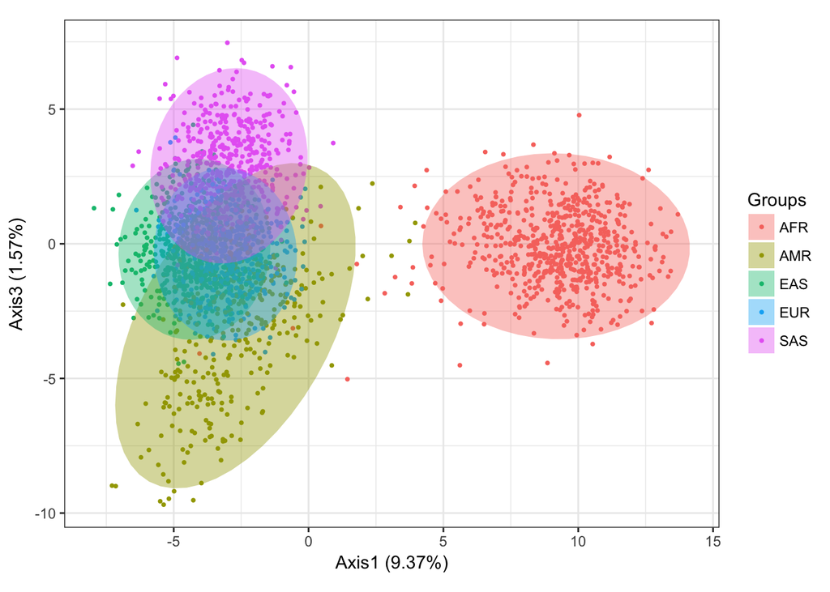

```r
ggord(dat.pca$ipca,poplist.1000g$Superpopulation.code,vec_ext=0,txt=NULL,arrow=0,ellipse=TRUE,size=1,axes=c("1","3"))
```

But does this mean that the eugenecists were right, and that race and genotype are inextricably linked? We can address this in two ways. First, we can look at the variance explained by the PC’s, just as we did for the salamanders:

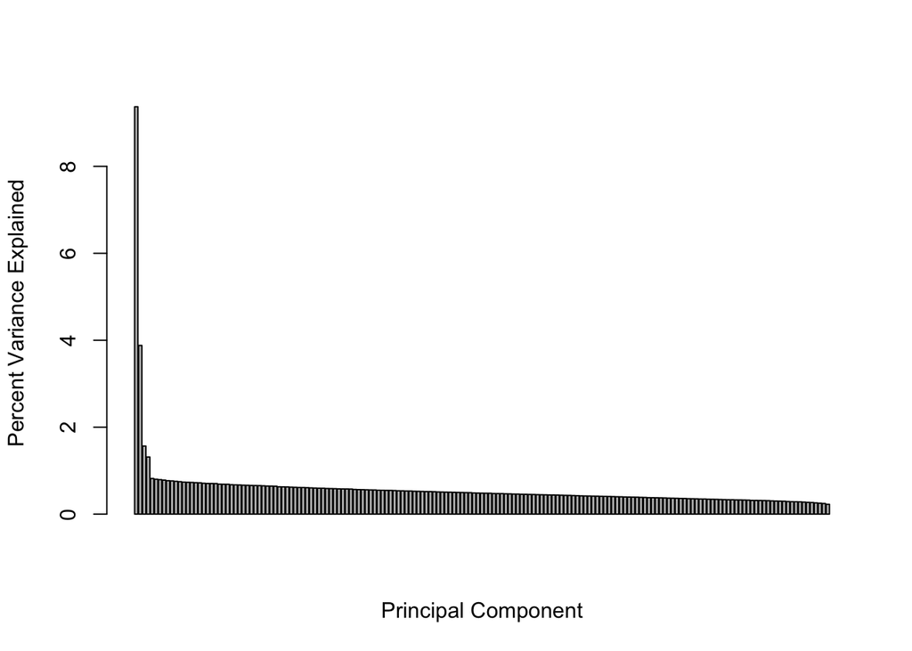

```r
barplot(100*dat.pca$ipca$eig/sum(dat.pca$ipca$eig),xlab="Principal Component",ylab="Percent Variance Explained")
```

And we see that the firat two components explain about 13% of the total variance - in other words there is a heck of a lot more genetic similarity among populations that there are differences between them. Second, we can do nested F statistic analysis of these data, based on differentiation among populations within superpopulations, and after a while we get the following:

```r
dat.hf <-genind2hierfstat(dat.gen)
levels <-data.frame(poplist.1000g[,3:2])

f.human <-varcomp.glob(levels,dat.hf[,-1])
kable(f.human$F)
```

|  | Superpopulation.code | Population.code | Ind |
| --- | --- | --- | --- |
| Total | 0.0930831 | 0.1004695 | 0.1033086 |
| Superpopulation.code | 0.0000000 | 0.0081446 | 0.0112751 |
| Population.code | 0.0000000 | 0.0000000 | 0.0031562 |

So the two kinds of analyses lead to similar results

# Conclusions

PCA is often a great way to start doing this sort of analysis, and you will encounter it in the literature frequently. Here we used genotypes as input; we could also use a distance matrix composed, for example, of pairwise Fst measures. But remember - those are based on our assumptions about population structure - what we have done here is not. But even so, the output we have is of rather limited informativeness. To refine our analysis further, we need a much better way of assigning genotypes to groups, and then using the results to construct meaningful biological hypotheses.

# References

Mullen, Lindy B., H. Arthur Woods, Michael K. Schwartz, Adam J. Sepulveda, and Winsor H. Lowe. 2010. “Scale-dependent genetic structure of the Idaho giant salamander (Dicamptodon aterrimus) in stream networks.” *Molecular Ecology* 19 (5): 898–909. doi:10.1111/j.1365-294X.2010.04541.x.